# Научная презентация 9

Дисциплина:Операционные системы

Алехин Давид Андреевич

Российский университет дружбы народов, Москва, Россия

Математический институт имени Никольского, Москва, Россия

06.03.25

# Информация

## Докладчик

- Алехин Давид Андреевич
- Студент
- Студент НММбд-01-24
- Российский университет дружбы народов
- 1132246830@pfur.ru
- https://github.com/trustdef

[figure not shown]

# Элементы презентации

## Актуальность

- Важно уметь работать с mc.

## Цели и задачи

- Ознакомление с файловой системой Linux, её структурой, именами и содержанием каталогов. Приобретение практических навыков по применению команд для работы с файлами и каталогами, по управлению процессами, по проверке использования диска и обслуживанию файловой системы.

## Материалы и методы

- fedora-linux

## Содержание исследования

Изучим информацию о mc при помощи справки man. Воспользуемся справкой и узнаем что для того чтобы войти в командную оболочку мы должны ввести в командной строке mc. Запустим из командной строки mc (рис. [-@fig:001]).

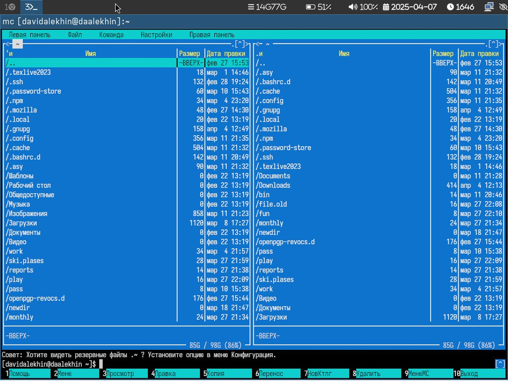

1

## Содержание исследования

Выполните несколько операций в mc, используя управляющие клавиши (рис. [-@fig:002], [-@fig:003]).

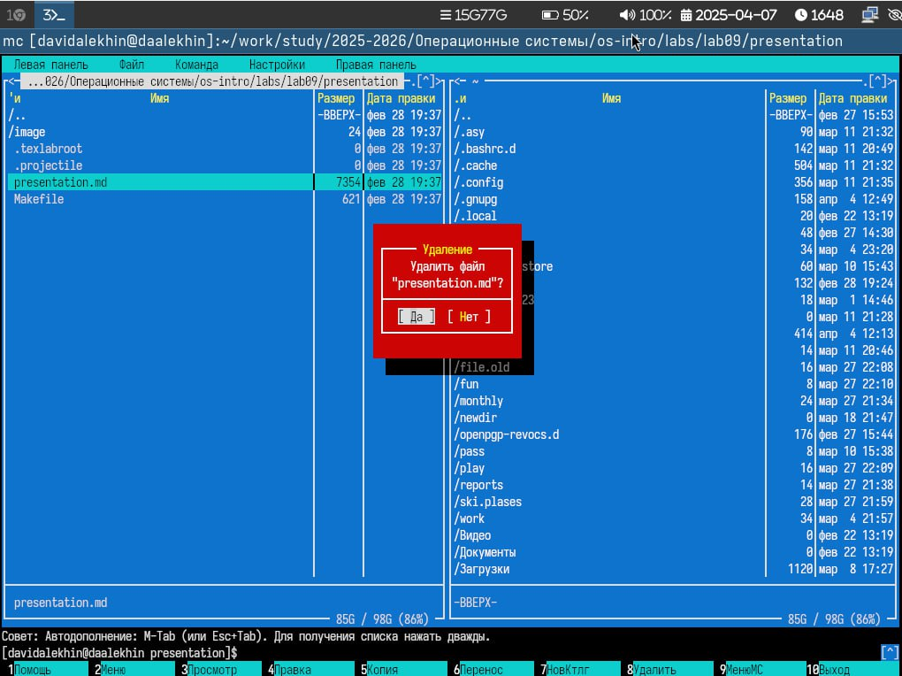

2

## Содержание исследования

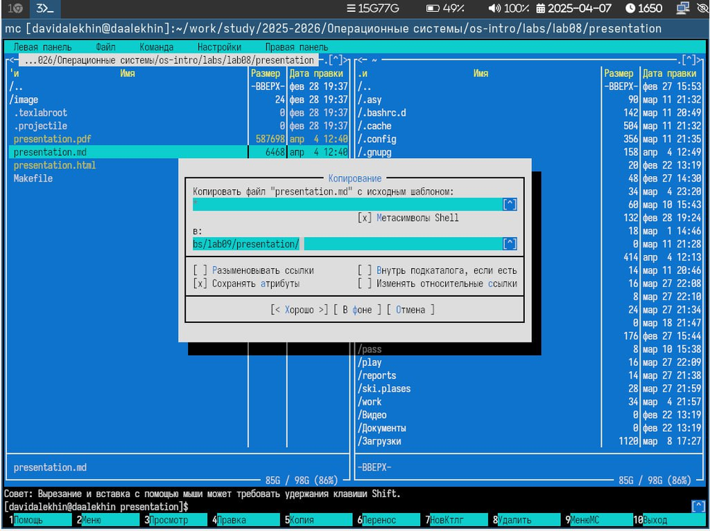

3

## Содержание исследования

Выполните основные команды меню левой панели (рис. [-@fig:004], [-@fig:005], [-@fig:006]).

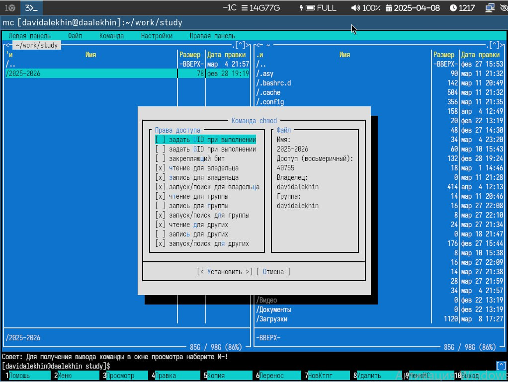

4

## Содержание исследования

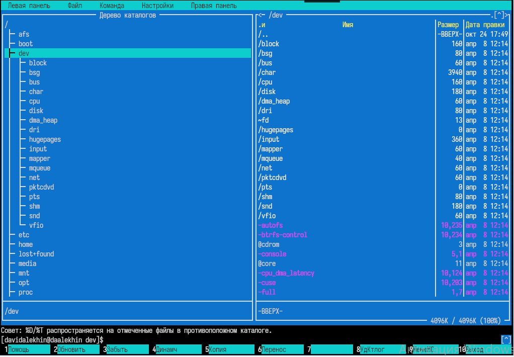

5

## Содержание исследования

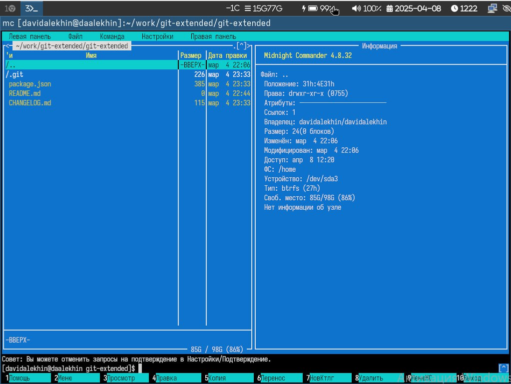

6

## Содержание исследования

Используя возможности подменю Файл , выполним: (рис. [-@fig:007], [-@fig:008], [-@fig:009], [-@fig:010]).

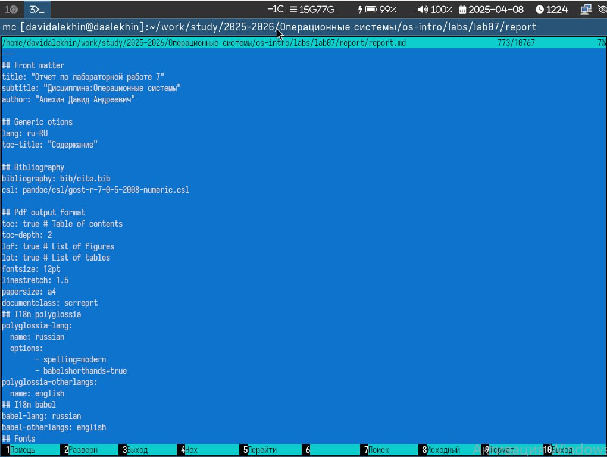

7

## Содержание исследования

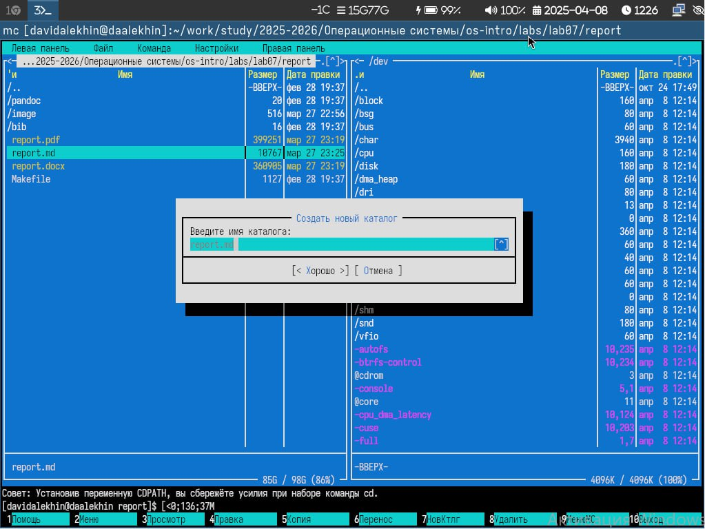

8

## Содержание исследования

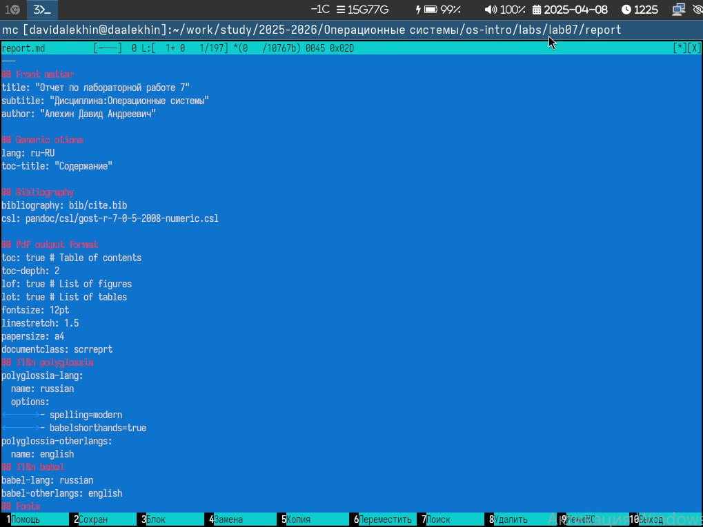

9

## Содержание исследования

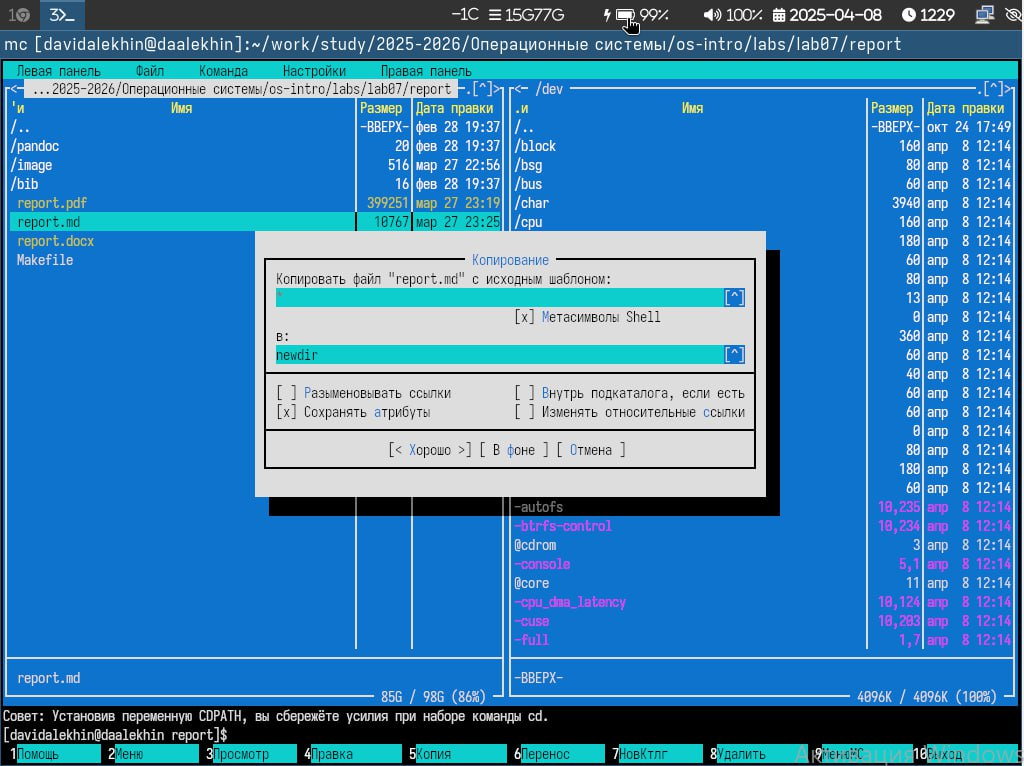

10

## Содержание исследования

С помощью соответствующих средств подменю Команда осуществите: (рис. [-@fig:011], [-@fig:012], [-@fig:013], [-@fig:014]).

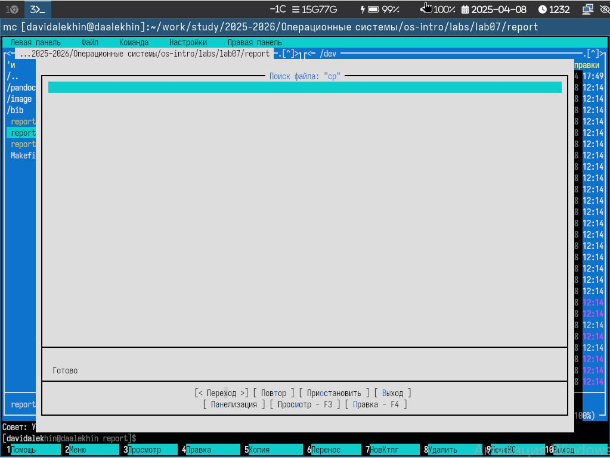

11

## Содержание исследования

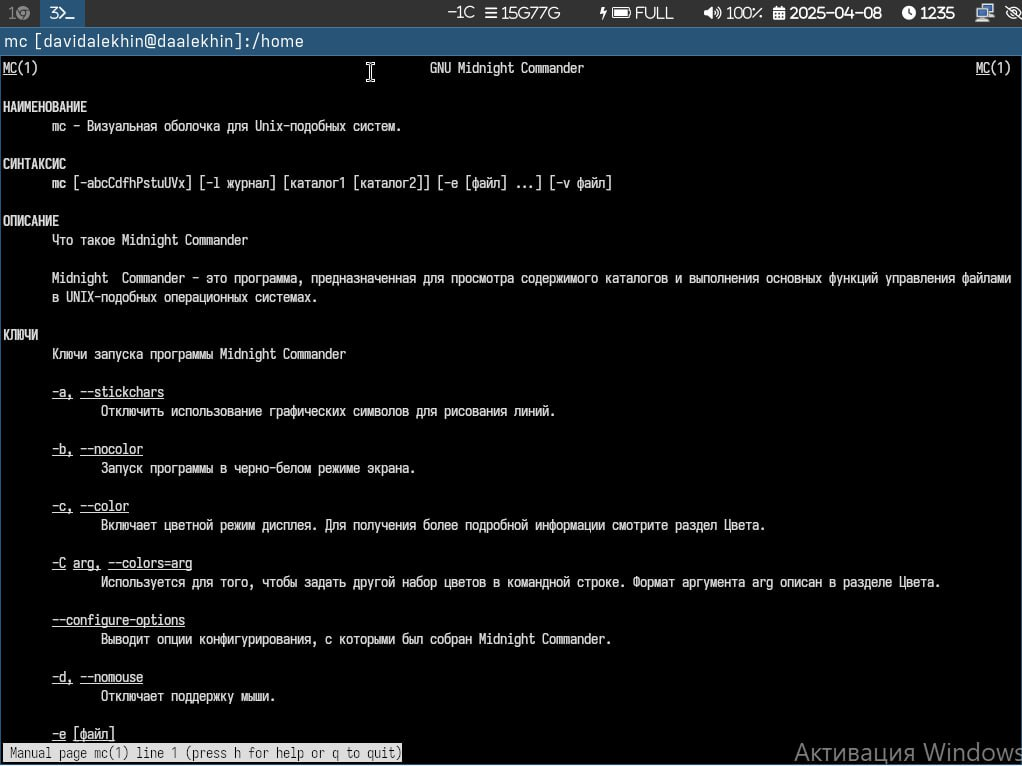

12

## Содержание исследования

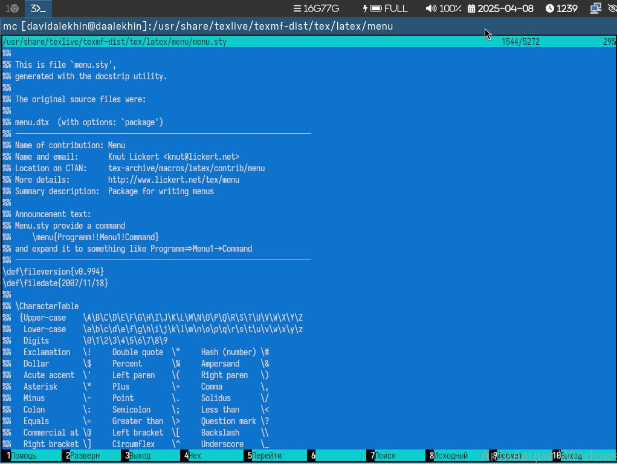

13

## Содержание исследования

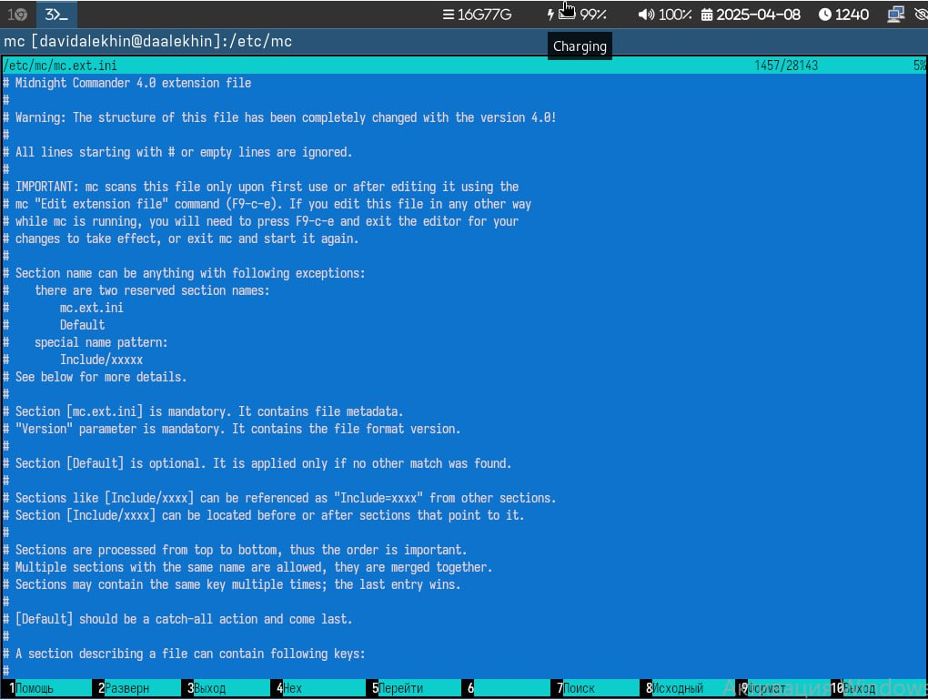

14

## Содержание исследования

Создадим текстовой файл text.txt. Откроем этот файл с помощью встроенного в mc редактора, и вставим в открытый файл небольшой фрагмент текста, скопированный из любого другого файла или Интернета. Проделаем с текстом следующие манипуляции, используя горячие клавиши: Удалим строку текста. - F8 Выделим фрагмент текста и скопируйте его на новую строку. - F5 Сохраним файл. - F2 Отменим последнее действие. - Ctrl+U Перейдем в конец файла - PageDown или Ctrl+X Перейдем в начало файла - PageUp или Ctrl+Z Откроем файл с исходным текстом на языке программирования C (рис. [-@fig:015], [-@fig:016]).

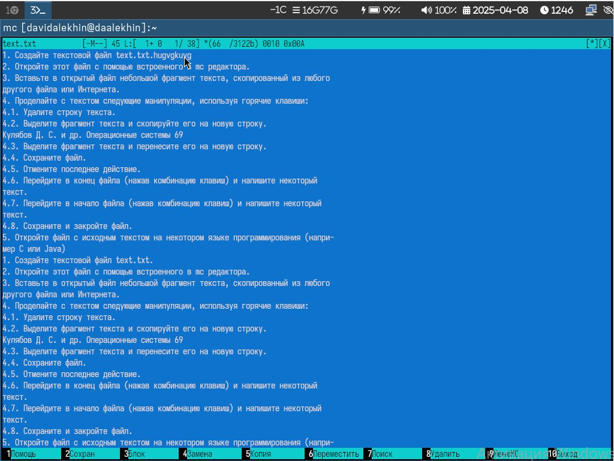

15

## Содержание исследования

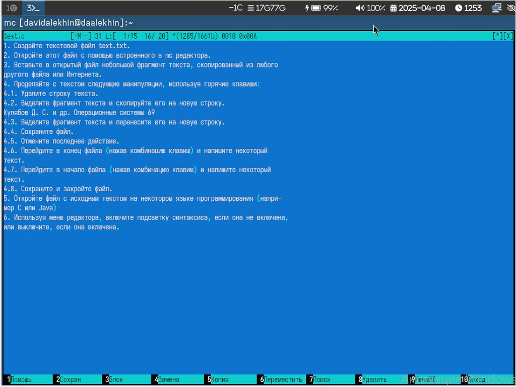

16

## Результаты

В данной работе мы ознакомились с инструментами командной оболочки Midnight Commander. Приобрели навыки практической работы по просмотру каталогов и файлов.

## Итоговый слайд

В теории, теория и практика неразделимы. На практике это не так. Yoggi Berra